# Windmill HW 1

Ethan Kemeny & Chris Trippe

9/19/2018

1. It can be costly to produce windmills. Companies often will use reference sites as an indicator of how efficient a canadite site will be. Using the data we will determine how good of a predictor reference sites are, as well as be able to predict canadate site speeds using the reference speeds. Using statistical modeling, we can produce quanitittive estimates and be able to better understand the actueal relationship between reference and canadite sites.

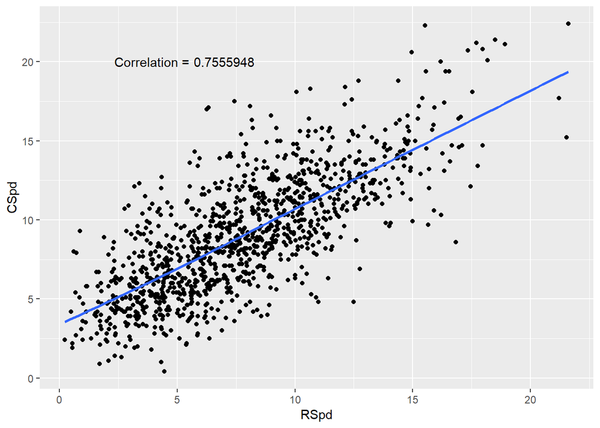

2. The correlation is 0.76 which implies a relatively strong, positive relationship between the speed. As the reference speed increases so does the canadite site speed. Most of the speeds found at reference sites are below 15, which would mean there are potential outliers for speeds greater than 15. Throughout the graph, even though there are less data points after a reference speed of 15, the variation appears to be approximately the same throughout.
3. $y_i = \beta_0 + \beta_1x_i$ $y_i$ is the speed of the $i^{th}$ candidate site. $x_i$ is the speed of the $i^{th}$ reference site. If the speed at a reference site is 0, then $\beta_0$ is the expected speed of the candidate site. For every increase in 1 unit of speed for the reference site, the candidate site is expected to increase by $\beta_1$ units of speed. In order to use this simple linear regression model, we are assuming that the relationship between reference and candidate speed is linear, the candidate speeds are independent of each other, the data points are normally distributed about the regression line, and the variation of the residuals is equal across the regression line.

```r
slr_wind <- lm(CSpd~RSpd, data = windmills)
coef(slr_wind)
```

```
## (Intercept)        RSpd
##   3.1412324   0.7557333
```

The fitted model for the wind speeds is:
$$y_i = 3.1412324 + 0.755733x_i$$
If the speed at a reference site is 0, then 3.14 is the expected speed of the candidate site. For every increase in 1 unit of speed for the reference site, the candidate site is expected to increase by 0.76 units of speed.

```
## RSpd = 12 RSpd = 30
##  12.21003  25.81323
```

Now that we have a fitted model, we can use it to predict the wind speed at candidate sites. If someone has a measured wind speed at a reference site, the reference site being the x value, they can simply plug it in to the fitted model formula and obtain an expected value for a nearby candidate site. For example, if the reference site has a wind speed of 12:
$$y = 3.1412324 + (0.755733 \times 12) = 12.21$$
The expected value for the speed of the nearby candidite site is 12.21 when the reference site has a wind speed of 12.

```
## The range of the reference site wind speeds are between the values 0.2221 and 21.6015.
```

The fitted model that was calculated uses wind speeds from reference sites between these values. The model does not account for anything that happens outside this range, so it is unkown exactly what the relationship between the reference site and candidate site wind speeds will be. If we find that a reference site has a wind speed of 30, we obtain the following prediction for a corresponding candidate site:
$$y = 3.1412324 + (0.755733 \times 30) = 25.81$$
However, since the model was fitted around reference site wind speeds between 0.2221 and 21.6015, a range that does not include wind speeds around 30, it cannot be concluded that a reference site wind speed of 30 will predict an estimated 25.81 wind speed for a nearby candidate site.